# ETC3250 Project

### Interpretation of the frequency axis

I have intentionally suppressed the axis label “kHz”, because as discussed earlier, the frequency across our sound samples is not constant, so the axis label would be inaccurate. Instead, the frequency axis can be interpreted as the reciprocal of the number of samples a component sine wave takes to complete a cycle: the wavelength. To illustrate, consider the waveform `0, 1, 0, -1`, which has a wavelength 4. The frequency is then 1/4, which can be read directly from the spectrogram:

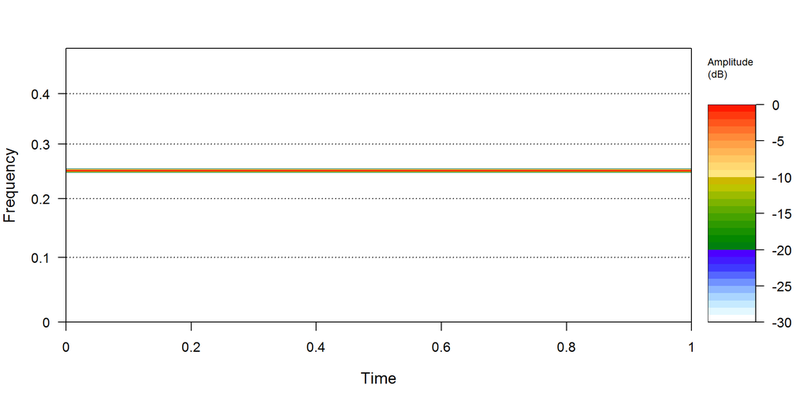

```r
spectro(rep(c(0, 1, 0, -1), 250), f=1000, wl=499, ovlp=0, tlab="Time", flab="Frequency", oma=c(0,0,2,0), flog=TRUE)
```

It is interesting to note a fundamental property of waves that arises here: the Heisenberg Uncertainty Principle. We need to choose a tradeoff between time resolution (small window length `wl`) and frequency resolution (large `wl`).

For example, if we wanted to know the approximate frequency distribution at a highly specific point in time, we would have to use the following spectrogram, which is much “fuzzier” in the frequency axis:

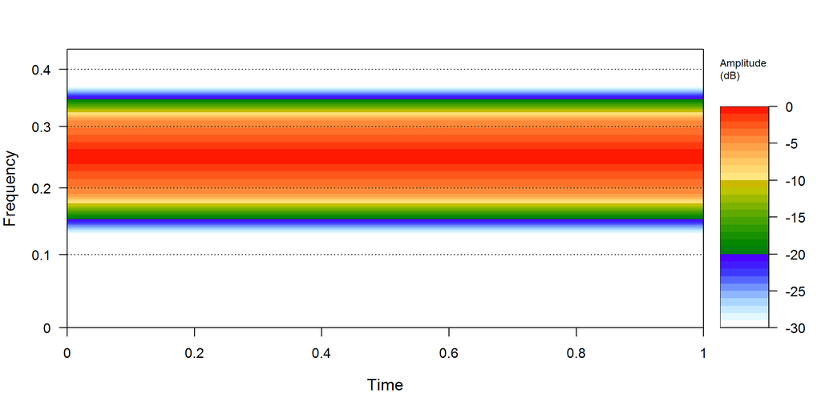

```r
spectro(rep(c(0, 1, 0, -1), 250), f=1000, wl=16, ovlp=0, tlab="Time", flab="Frequency", oma=c(0,0,2,0), flog=TRUE)
```

As our raw Fourier Transform already gives us high resolution frequency data, to extract more information from our sound data, we will use a relatively low window length of 120. This allows us to track frequency changes over time.

### Observations about the spectrograms of the training data

From these spectrograms, I noticed an interesting feature. Sibilant sounds, such as s and sh, tend to be difficult to tell apart between Di and Souhaib. Consider the following sound samples:

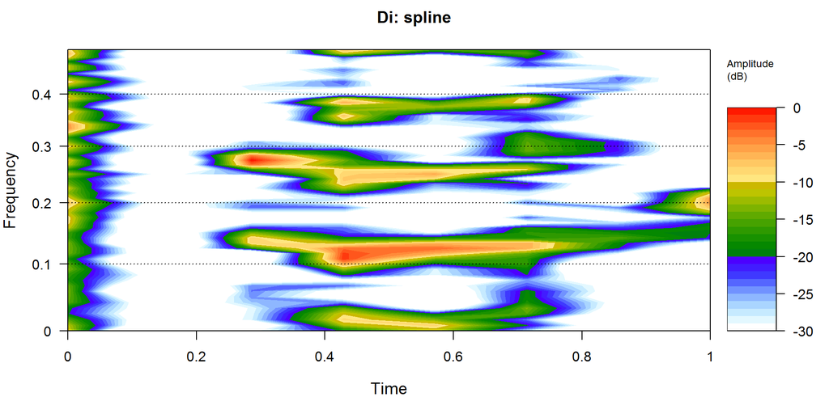

```r
spectro(as.numeric(tr[72,]), f=1000, wl=120, ovlp=0, tlab="Time", flab="Frequency", oma=c(0,0,2,0), flog=TRUE)
title("Di: spline", outer=TRUE)
```

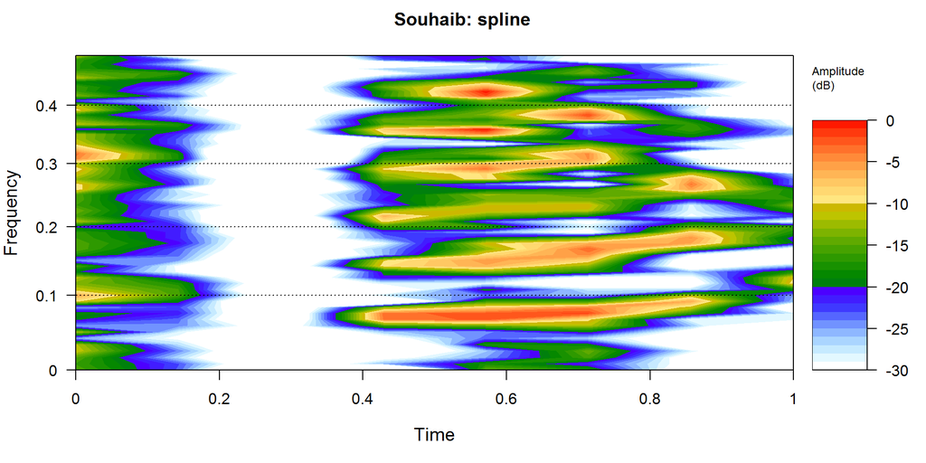

```r
spectro(as.numeric(tr[74,]), f=1000, wl=120, ovlp=0, tlab="Time", flab="Frequency", oma=c(0,0,2,0), flog=TRUE)
title("Souhaib: spline", outer=TRUE)
```

Notice that towards the left of the plot, the frequency distribution is almost uniform. This is because sibilant sounds are spectrally similar to white noise, which is by definition noise with a uniform frequency distribution!

Let’s compare four cases, all of different words to see if there are any common patterns.

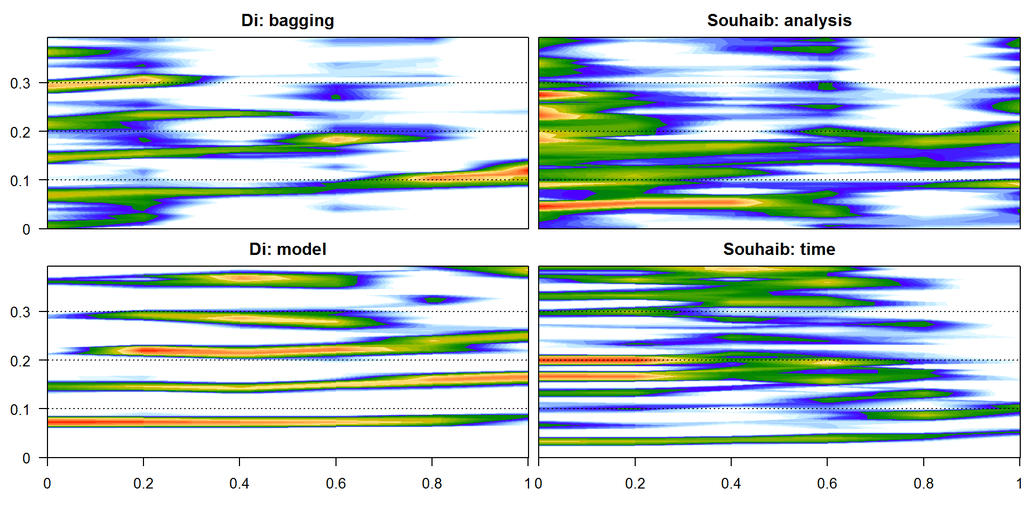

```r
layout(matrix(c(1,2,3,4), 2, 2))
par(oma = c(3,2.2,0,0) + 0.1, mar = c(0,0.4,2,0) + 0.1)
par(xaxt="n", yaxt="s")
spectro(as.numeric(tr[9,100:900]), f=800, wl=120, ovlp=0, scale=FALSE, flab="Relative Frequency", main="Di: bagging")
par(xaxt="s", yaxt="s")
spectro(as.numeric(tr[60,100:900]), f=800, wl=120, ovlp=0, scale=FALSE, flab="Relative Frequency", main="Di: model")
par(xaxt="n", yaxt="n")
spectro(as.numeric(tr[6,100:900]), f=800, wl=120, ovlp=0, scale=FALSE, flab="Relative Frequency", main="Souhaib: analysis")
par(xaxt="s", yaxt="n")
spectro(as.numeric(tr[76,100:900]), f=800, wl=120, ovlp=0, scale=FALSE, flab="Relative Frequency", main="Souhaib: time")
```

What a fantastic result! Even over different words, the main features of Di and Souhaib’s spectrogram’s appear to be relatively constant. Recall that the major problem we first identified with our waveforms was that they were highly variable between words, but not between speakers. We have now flipped this: **the variance between speakers is high, but not between words!**

To illustrate how helpful the spectrogram will be to our classifier, consider the following basic dimension reduction of a waveform to two variables: the two most acute peaks of its spectrum.

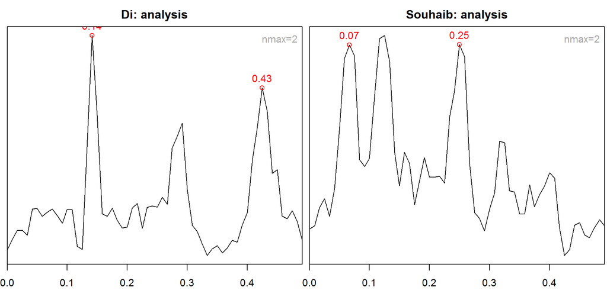

```r
layout(matrix(c(1,2), ncol=2))
par(oma = c(3,0,0,0) + 0.1, mar = c(0,0.4,2,0) + 0.1)
fpeaks(meanspec(as.numeric(tr[1,]), f=1000, wl=120, plot=FALSE), nmax=2, title=FALSE)
title("Di: analysis")
fpeaks(meanspec(as.numeric(tr[2,]), f=1000, wl=120, plot=FALSE), nmax=2, title=FALSE) #peaks with highest slopes
title("Souhaib: analysis")
```

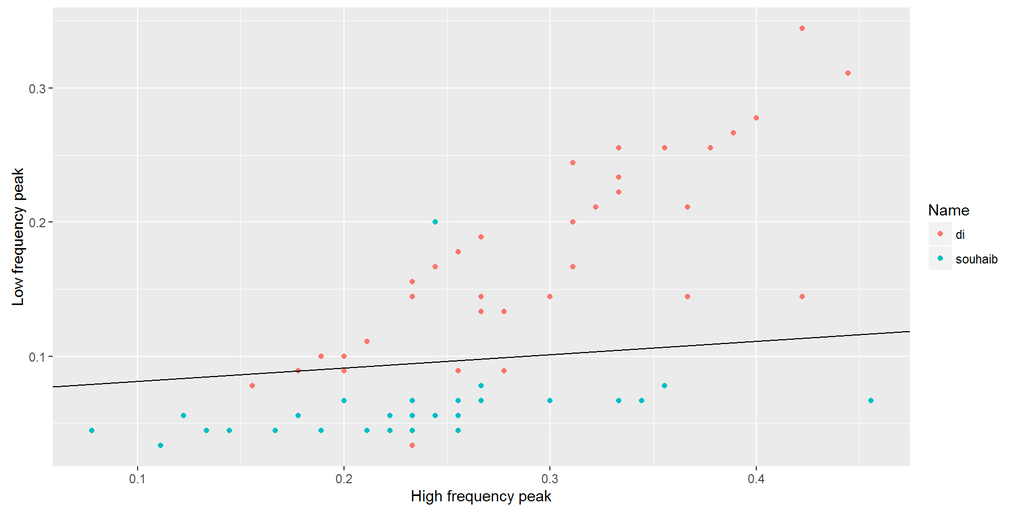

```r
spec_peaks <- data.frame(apply(tr, 1, function(x){fpeaks(meanspec(x, f=1000, wl=90, plot=FALSE), nmax=2, plot=FALSE)[2,1]}),
                         apply(tr, 1, function(x){fpeaks(meanspec(x, f=1000, wl=90, plot=FALSE), nmax=2, plot=FALSE)[1,1]}))

separation_plot(spec_peaks, "High frequency peak", "Low frequency peak")
```

```r
wrong_tally <- update_tally(spec_peaks, wrong_tally)
```

By taking a window of this spectrum over time, we tap into a particularly rich source of differentiation between Di and Souhaib’s speech.

## The Zero Crossing Rate

In the course of our spectrogram analysis, we noticed that we had some difficulty differentiating between the “s” sounds of Di and Souhaib. This sound is known as an unvoiced sound, as the vocal cords do not vibrate to produce it.

The instantaneous zero crossing rate is a simple (but rough) way of classifying speech as voiced or unvoiced. The total crossing rate, then, is a rough proxy for the amount of “aspiration” the word spoken. Unfortunately, this statistic is likely to vary across words quite a lot, however for our purposes will be better than nothing.

Due to the influence of unvoiced sounds on the spectrogram, it will be useful to quantify roughly how aspirated a phrase is in our test data. As we will see in the final model, by interacting our spectrogram values with our zero crossing rate for each sample, we gain a crucial way of differentiating the more difficult to classify sounds. I believe this unusual combination of variables was invaluable in achieving my final Kaggle score.

Consider the following function:

```r
zero_crosses <- function(x) {
  total <- 0
  previous <- x[1] > 0
  for (i in 2:length(x)) {
    current <- x[i] > 0
    total <- total + (previous == current)
    previous <- current
  }
  return(total)
}
```

Then plotting the zero crossing rate for our training samples:

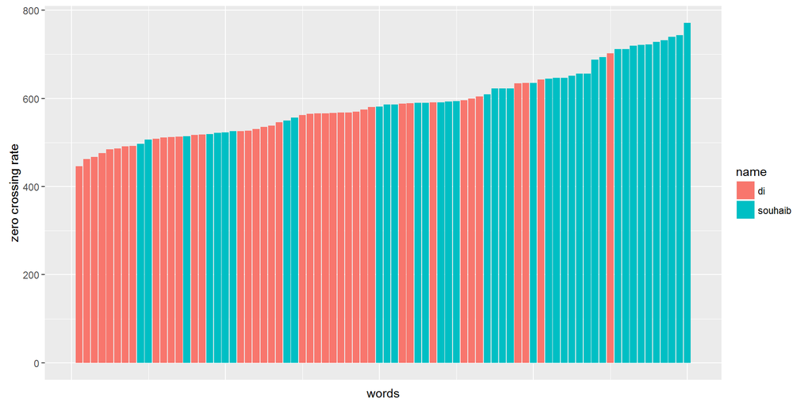

```r
tr_zc <- data.frame(name=tr_answers, zc=apply(tr, 1, zero_crosses))
tr_zc <- arrange(tr_zc, zc)
ggplot(tr_zc, aes(x=1:80, y=zc, fill=name)) +
  geom_bar(stat="identity") +
  labs(x="words", y="zero crossing rate") +
  theme(axis.text.x = element_blank(), axis.ticks.x = element_blank())
```

```r
wrong_tally <- wrong_tally + as.numeric(factor(ifelse(apply(tr, 1, zero_crosses) > median(tr_zc$zc), "souhaib", "di")) != tr_answers)
```

Interestingly, it appears the zero crossing rate appears to itself have some predictive power. There are two possible explanations here:

1. Souhaib’s pronounciation of words is more aspirated than Di’s.
2. Souhaib’s word samples have longer silent sections on average. Silence also tends to have a higher zero crossing rate.

Personally, I favour the second explanation, but it is likely that some characteristic of speech also contributes to this effect. However, the zero crossing rate alone did not contribute to the predictive power of our classifier, so it appears only as an interaction term in the final model.

## Skewness

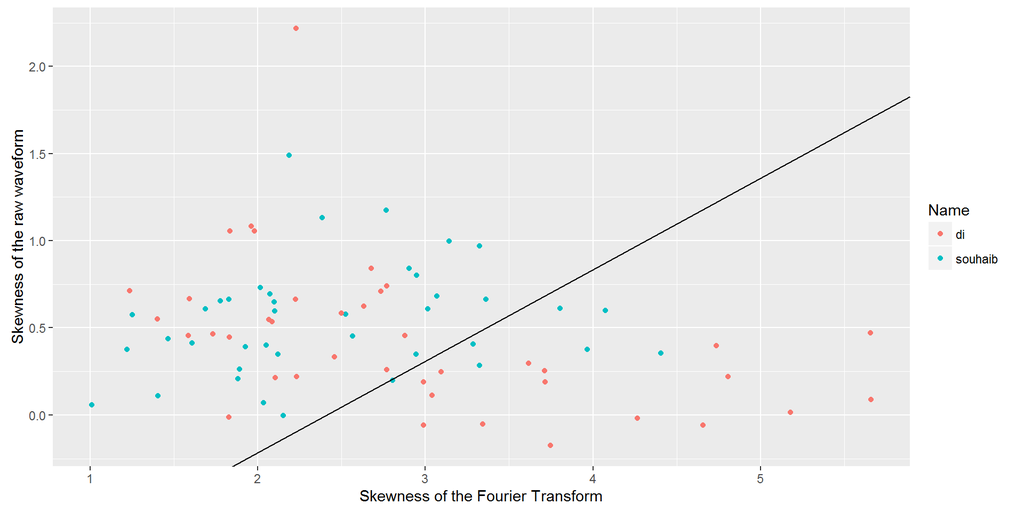

```r
tr_skewness <- data.frame(apply(tr, 1, function(x){skewness(abs(fft(x)))}), apply(tr, 1, skewness))
separation_plot(tr_skewness, "Skewness of the Fourier Transform", "Skewness of the raw waveform")
```

```r
wrong_tally <- update_tally(tr_skewness, wrong_tally)
```

Such a simple statistic is a relatively poor metric, but it does give us new information about our sounds about the change in amplitude, so will be helpful in our final model.

## Summary of extracted features

These features will be all we need in our final model. But before we construct the model, let’s investigate our tally of wrong predictions we have kept from these simples two-dimensional measures.

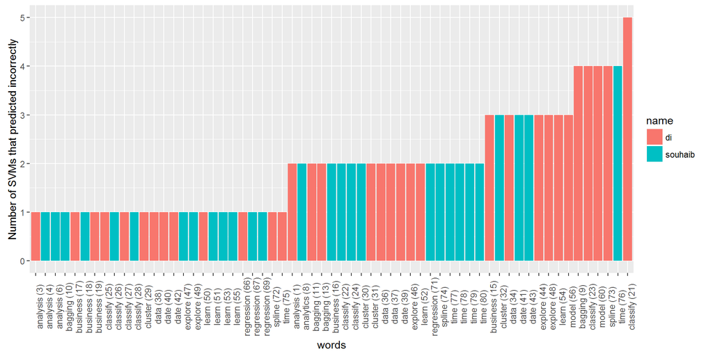

```r
wrong_tally <- data.frame(tr_wide[,1:3], wrong=wrong_tally) %>%
  filter(wrong != 0)

wrong_tally$phrase <- paste0(wrong_tally$phrase, " (", wrong_tally$id, ")")

ggplot(wrong_tally, aes(x=reorder(phrase, wrong), y=wrong, fill=name)) +
  geom_bar(stat="identity", position="stack") +
  labs(x="words", y="Number of SVMs that predicted incorrectly") +
  theme(axis.text.x = element_text(angle=90))
```

This is a good result: Of six two-variable linear SVMs fitted, every word was classified correctly *at least* once, and only one word was classified correctly *only* once. With a good non-linear model, we should be able to achieve a good classification score.

# The Model

Through the course of my participation in the Kaggle competition, I attempted to fit many different types of models. These including OLS regression, k-Nearest-Neighbour, Support Vector Machines, decision trees, random forests and boosted forests.

Ultimately, the random forest was the best model for two reasons:

1. It is relatively robust to low-importance observations. This is important for our classifier as our extracted features are relatively high-dimensional.
2. It allows for complex non-linearity. The relationship between the spectrogram and the speaker in particular is highly complex, so the ability of random forests to encode complex relationships is particularly appealing.

The best model with our explored features, selected based on the OOB error rate, includes the following variables:

```r
tr_predictors <- cbind(tr, tr_fft, tr_spec, tr_spec * tr_zcr, tr_skew)
names(tr_predictors) <- paste0("X", 1:2221)
ts_predictors <- cbind(ts, ts_fft, ts_spec, ts_spec * ts_zcr, ts_skew)
names(ts_predictors) <- paste0("X", 1:2221)
```

```r
model <- randomForest(x=tr_predictors, y=tr_answers, ntree=1499, mtry=20)
model
```

```
##
## Call:
##  randomForest(x = tr_predictors, y = tr_answers, ntree = 1499,      mtry = 20)
##                Type of random forest: classification
##                      Number of trees: 1499
## No. of variables tried at each split: 20
##
##         OOB estimate of  error rate: 6.25%
## Confusion matrix:
##         di souhaib class.error
## di      35       5       0.125
## souhaib  0      40       0.000
```

Our model has a 6.25% “out of bag” error rate. As the out of bag error rate excludes trees that were trained on the specific sample, we can be confident that test-set predictions will have a similar error rate, assuming the test set data is similar to the training set data.

## Further Analysis

Let’s examine the training samples that our random forest misclassified.

```r
wrong <- which(model$predicted != tr_answers)
tr_wide[wrong, 1:4]
```

```
##    id   phrase name rep
## 15 15 business   di   6
## 19 19 business   di   6
## 21 21 classify   di   8
## 23 23 classify   di   8
## 34 34     data   di   6
```

Interestingly, the model’s misclassifications were all instances of words spoken by Di that the model predicted as words spoken by Souhaib. It also appears that, with the exception of “data”, all misclassified words have a strong “s” sound, which we identified earlier is likely to cause difficulty due to the similarity of this sound and white noise.

Using the `seewave::listen()` function, it seems that these samples are particularly noisy compared to others.

I also noticed that the phrase “data” seems to be a relatively short compared with others recordings. In fact, when listening to it with `f=1400`, which was about right for “analysis”, the pitch sounds far too low for a sample of Di, even to the human ear. This is likely why our model assumed it was a sample of Souhaib.

Let’s now examine the confidence scores of the model:

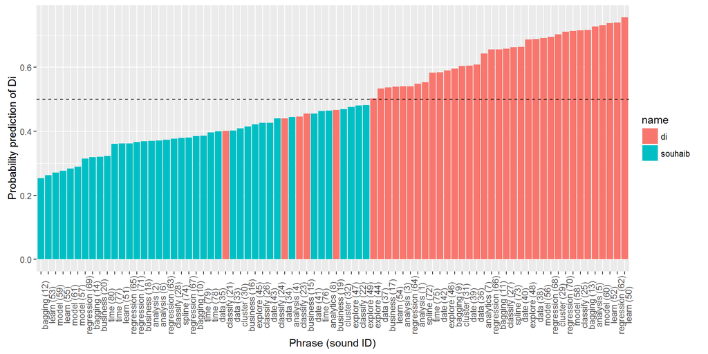

```r
confidence <- data.frame(id=1:80, phrase=paste0(tr_wide$phrase, " (", 1:80, ")"), name=tr_answers, model$votes, diff=0.5*abs(model$votes[,1] - model$votes[,2])) %>%
  arrange(desc(diff))

ggplot(confidence, aes(reorder(phrase, di), di, fill=name)) +
  geom_bar(stat="identity", position="dodge") +
  labs(x="Phrase (sound ID)", y="Probability prediction of Di") +
  theme(axis.text.x = element_text(angle=90)) +
  geom_abline(data=NULL, slope=0, intercept=0.5, linetype="dashed")
```

```r
subset(confidence, id %in% wrong)
```

```
##    id        phrase name        di   souhaib       diff
## 49 21 classify (21)   di 0.4011299 0.5988701 0.09887006
## 61 34     data (34)   di 0.4409006 0.5590994 0.05909944
## 63 23 classify (23)   di 0.4467005 0.5532995 0.05329949
## 66 15 business (15)   di 0.4550360 0.5449640 0.04496403
## 75 19 business (19)   di 0.4664247 0.5335753 0.03357532
```

The “most wrong” OOB prediction was for id 21, classify spoken by Di, which our random forest predicted as Souhaib with 60% confidence. This was the same observation that was incorrectly predicted by 5 of 6 of our simple SVM models.

Finally, here is the raw output of the Random Forest model on the test set data.

```r
predict(model, ts_predictors)
```

```
##       1       2       3       4       5       6       7       8       9
## souhaib      di      di      di      di      di souhaib souhaib      di
##      10      11      12      13      14      15      16      17      18
## souhaib      di      di souhaib      di      di      di      di souhaib
##      19      20      21      22      23      24      25      26      27
##      di souhaib      di      di souhaib souhaib souhaib      di      di
##      28      29      30      31      32      33      34      35      36
## souhaib souhaib souhaib souhaib      di      di souhaib souhaib      di
##      37      38      39      40      41      42
## souhaib      di souhaib souhaib souhaib souhaib
## Levels: di souhaib
```